# Preproceso de los datos del Titánic

Luis Larbec Sánchez

2026-03-20

# 1. Carga y exploración inicial de los datos

Procedemos a insertar el dataset proporcionado por el enunciado y su posterior análisis del tipo de dato por columna con la función `sapply()`.

Con la función `duplicated()` comprobamos la existencia de pasajeros duplicados. En nuestro caso, se detectaron identificadores repetidos.

Para corregir la inconsistencia:

- Se mantuvieron los identificadores válidos.
- Se asignaron nuevos identificadores únicos solo a los registros duplicados.

Tras la corrección, **no quedaron identificadores repetidos**.

```r
# Cargamos librería 'readxl' para el uso de la función read_excel
library(readxl)

# Almacenamos la información del excel en la variable 'datos'
datos <- read_excel("titanic_dataset.xlsx")

# Analizamos el tipo de dato de cada columna de nuestra variable 'datos'
sapply(datos,class)
```

```
## PassengerId    Survived      Pclass        Name         Sex         Age
##   "numeric"   "numeric"   "numeric" "character" "character"   "numeric"
##       SibSp       Parch      Ticket        Fare       Cabin    Embarked
##   "numeric"   "numeric" "character" "character" "character" "character"
```

```r
# Comprobamos la duplicidad del identificador -> 'Passenger_ID'
dup <- duplicated(datos$PassengerId)
head(dup, 60)
```

```
##  [1] FALSE FALSE FALSE FALSE FALSE FALSE FALSE FALSE FALSE FALSE FALSE FALSE
## [13] FALSE FALSE FALSE FALSE FALSE FALSE FALSE FALSE FALSE FALSE FALSE FALSE
## [25] FALSE FALSE FALSE FALSE FALSE FALSE FALSE FALSE FALSE FALSE FALSE FALSE
## [37] FALSE FALSE FALSE FALSE FALSE FALSE FALSE FALSE FALSE FALSE FALSE FALSE
## [49] FALSE FALSE FALSE FALSE FALSE FALSE FALSE FALSE FALSE FALSE FALSE FALSE
```

```r
# En caso de existir algún identificador repetido, reasignamos la ID del segundo
datos$PassengerId[dup] <- seq(max(datos$PassengerId, na.rm = TRUE) + 1,
                              by = 1,
                              length.out = sum(dup))
```

## 2. Tratamiento de variables cuantitativas

En primer lugar, creamos una columna adicional `FamS` (tamaño de la familia), correspondiente a la suma de `SibSp`, `Parch` y el propio pasajero.

```r
# Creación columna nueva, 'FamS'
datos$FamS <- datos$SibSp + datos$Parch + 1
# Verificamos la existencia de valores en la columna
head(datos$FamS)
```

```
## [1] 2 2 1 2 1 1
```

La única conversión que tenemos que hacer a tipo numérico de las columnas es `Fare`:

```r
# Conversión variable 'Fare' de character a numeric.
datos$Fare <- as.numeric(datos$Fare)
```

Para cada columna a analizar, establecemos lo que es un **valor no-erróneo**, y, a partir de ahí, corregimos con `NA` los que no lo sean. Procedemos a crear gráficos que nos ayuden a establecer esos valores no-erróneos.

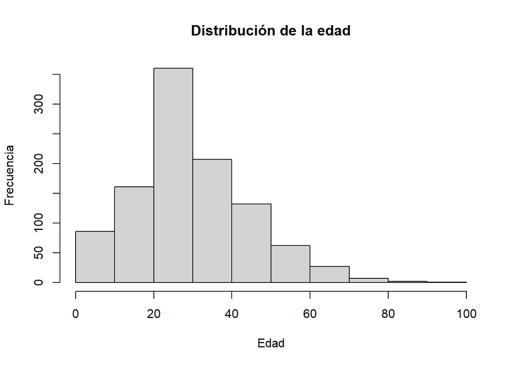

```r
hist(datos$Age,
     main = "Distribución de la edad",
     xlab = "Edad",
     ylab = "Frecuencia")
```

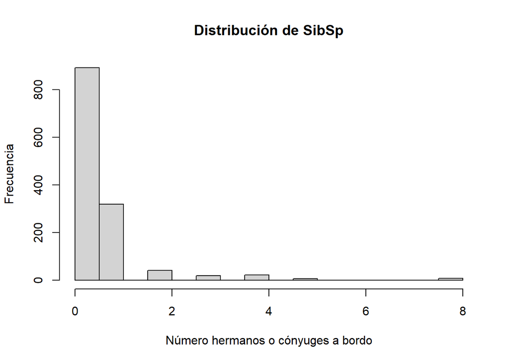

```r
hist(datos$SibSp,
     main = "Distribución de SibSp",
     xlab = "Número hermanos o cónyuges a bordo",
     ylab = "Frecuencia")
```

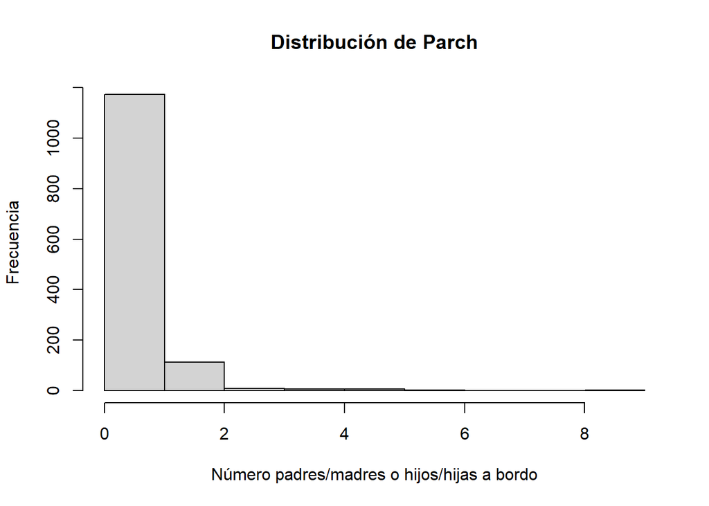

```r
hist(datos$Parch,
     main = "Distribución de Parch",
     xlab = "Número padres/madres o hijos/hijas a bordo",
     ylab = "Frecuencia")
```

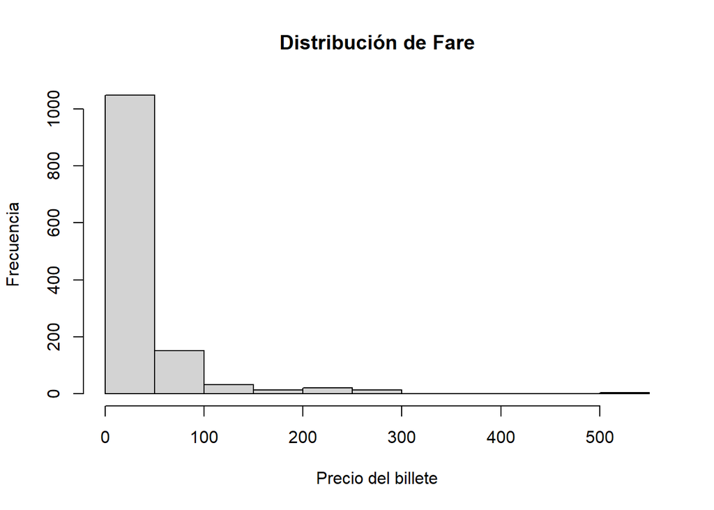

```r
hist(datos$Fare,
     main = "Distribución de Fare",
     xlab = "Precio del billete",
     ylab = "Frecuencia")
```

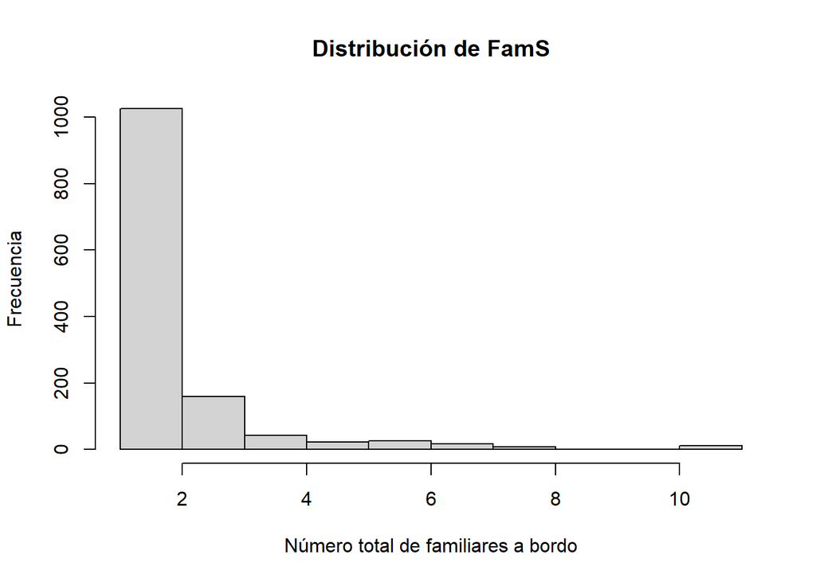

```r
hist(datos$FamS,
     main = "Distribución de FamS",
     xlab = "Número total de familiares a bordo",
     ylab = "Frecuencia")
```

Se establecen las siguientes reglas de validación:

- **Age**: valores entre *0 y 100 años*
- **SibSp, Parch y Fare**: valores **≥ 0**
- **FamS**: valores **≥ 1** (al menos el propio pasajero)

### 2.1. Edad (Age)

```r
# Nos aseguramos de que la edad estará comprendida entre 0 y 100 años
datos$Age[datos$Age < 0 | datos$Age > 100] <- NA
```

### 2.2. Número de hermanos/cónyuges (SibSp)

```r
# Nos aseguramos de que la variable será mayor o igual a 0
datos$SibSp[datos$SibSp < 0] <- NA
```

### 2.3. Número de padres/hijos (Parch)

```r
# Nos aseguramos de que la variable será mayor o igual a 0
datos$Parch[datos$Parch < 0] <- NA
```

### 2.4. Tarifa (Fare)

```r
# Nos aseguramos de que la variable será mayor o igual a 0
datos$Fare[datos$Fare < 0] <- NA
```

### 2.5. Tamaño de familia (FamS)

```r
# Nos aseguramos de que la variable será mayor o igual a 1
datos$FamS[datos$FamS < 1] <- NA
```

## 3. Tratamiento de variables categóricas

### 3.1. Supervivencia (Survived)

La variable `Survived` se transforma de tipo numérico a categórico, codificando:

- **1 → Yes**
- **0 → No**

Cualquier valor distinto se considera inválido y se reemplaza por `NA`.

```r
# Conversión variable 'Survived' de numeric a character
datos$Survived <- as.character(datos$Survived)

# Verificamos que la conversión se ha relizado correctamente
sapply(datos['Survived'], class)
```

```
##    Survived
## "character"
```

Una vez realizada la conversión, procedemos a cambiar el 1 por ‘Yes’ y el 0 por ‘No’. También escribiremos `NA` si en la celda no aparece nada o aparece un número distinto de 1 o 0.

```r
# Sustituimos el valor de la celda por NA si está vacía o sus números no son 1 o 0
datos$Survived[datos$Survived == "" | (datos$Survived != "1" & datos$Survived != "0")] <- NA

# Sustituimos los 0s por No y los 1s por Yes
datos$Survived[datos$Survived == "0"] <- "No"
datos$Survived[datos$Survived == "1"] <- "Yes"
```

Una vez que tenemos todo codificado, transformamos la variable `Survived` a tipo categórica (el enunciado nos lo pide), de modo que:

```r
# Conversión variable 'Survived' de character a categórica con los valores 'No' y 'Yes'
datos$Survived <- factor(datos$Survived, levels = c("No", "Yes"))
```

### 3.2. Clase del billete (Pclass)

Establecemos el rango válido para esta columna, que será de 1,2 o 3:

```r
# Evitamos que las variables de esta columna tengan valores fuera del rango permitido
datos$Pclass[datos$Pclass < 1 | datos$Pclass > 3] <- NA
```

Para el caso de esta variable, tenemos que transformarla en una variable categórica ordinal

```r
# Convertimos la variable 'Pclass' en un factor ordinal con niveles 1, 2 y 3
datos$Pclass <- factor(datos$Pclass,
                       levels = c(1, 2, 3),
                       ordered = TRUE)
```

### 3.3. Sexo (Sex)

Utilizamos la expresión `table(datos$Sex)` para observar los diferentes valores a lo largo de toda la tabla que hay en esta columna, esto nos permitirá adaptar el análisis de las diferentes celdas de acuerdo a la clasificación por género.

```r
table(datos$Sex)
```

```
##
##      F    Fem female      M   male   Male
##      2      2    462      5    833      5
```

Añadiremos a continuación un chunk para facilitar la clasificación en esta columna.

```r
# Recodificación valores columna Sex
datos$Sex[datos$Sex == 'F' | datos$Sex == 'Fem' | datos$Sex == 'female'] <- "Female"
datos$Sex[datos$Sex == 'M' | datos$Sex == 'male' | datos$Sex == 'Male'] <- "Male"
```

Convertimos también la variable de tipo *character* a *categórica*.

```r
# Conversión a variable categórica
datos$Sex <- factor(datos$Sex,
                    levels = c("Female","Male"))
```

### 3.4. Puerta de embarque (Embarked)

En primer lugar usaremos la expresión `table(datos$Embarked)` para ver los distintos valores existentes en la columna

```r
table(datos$Embarked)
```

```
##
##   c   C   q   Q   s   S
##  13 257  12 111  11 903
```

Procedemos a recodificar los valores:

```r
# Recodificación valores columna Embarked
datos$Embarked[datos$Embarked == "C" | datos$Embarked == "c"] <- "Cherbourg"
datos$Embarked[datos$Embarked == "Q" | datos$Embarked == "q"] <- "Queenstown"
datos$Embarked[datos$Embarked == "S" | datos$Embarked == "s"] <- "Southampton"
```

A continuación, como hemos hecho antes con las variables anteriores, la transformamos a *categórica*.

```r
# Conversión a variable categórica
datos$Embarked <- factor(datos$Embarked,
                         levels = c("Cherbourg",
                                    "Queenstown",
                                    "Southampton"))
```

## 4. Tratamiento de variables de texto

Como menciona el enunciado, a las variables `Name`, `Ticket` y `Cabin` (tipo texto) únicamente se les quitarán los espacios al inicio o al final de la cadena de texto, en caso de existir.

Además de añadir `NA` en caso de existir una celda totalmente en blanco.

```r
# Quitamos posibles espacios al inicio o final de la cadena de texto con la función trimws()
datos$Name <- trimws(datos$Name)
datos$Cabin <- trimws(datos$Cabin)
datos$Ticket <- trimws(datos$Ticket)

# Evitamos que celdas se queden vacías
datos$Name[datos$Name == ""] <- NA
datos$Ticket[datos$Ticket == ""] <- NA
datos$Cabin[datos$Cabin == ""] <- NA
```

## 5. Detección de valores atípicos (Outliers)

### 5.1. Edad (Age)

En primer lugar vamos a generar un diagrama de cajas (boxplot) para analizar los posibles valores extremos (outliers) en la variable `Age`.

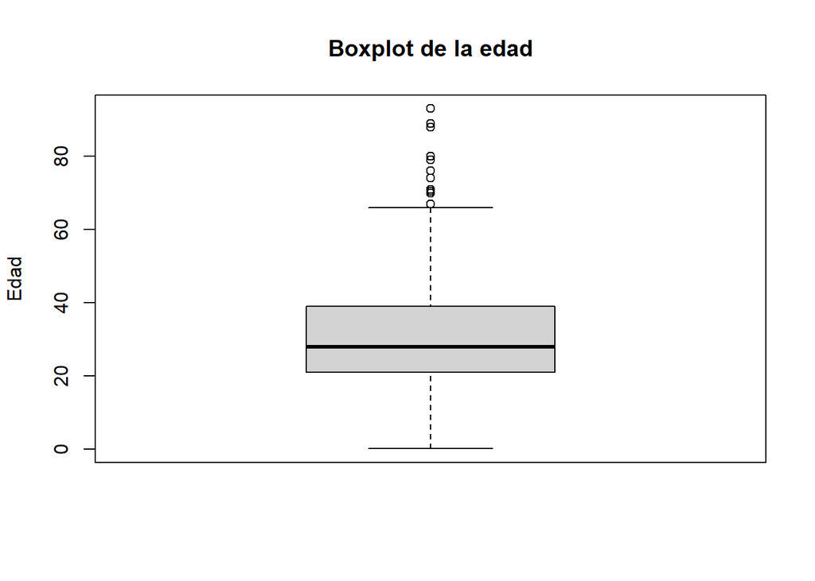

```r
boxplot(datos$Age,
        main = "Boxplot de la edad",
        ylab = "Edad")
```

Se identifican valores atípicos (*outliers*) mediante diagramas de caja (*boxplot*).

En el caso de `Age`, los valores extremos se sitúan entre **67 y 93 años**.  
Sin embargo, estos valores son **plausibles**, por lo que **no se eliminan**.

Ayudándonos de la función `stats()` veremos de qué edades se trata concretamente:

```r
# Aplicamos el método del rango intercuartílico para identificar los outliers
boxplot.stats(datos$Age)$out
```

```
##  [1] 93.0 71.0 70.5 89.0 71.0 80.0 70.0 70.0 74.0 79.0 67.0 76.0 88.0
```

El método del **rango intercuartílico** nos permite identificar que estos outliers van desde los **67 a los 93 años**. No obstante, se trata de **valores plausibles** de los pasajeros del Titanic, por lo que no se considerarán como errores de registro y se mantendrán dentro del conjunto de datos.

### 5.2. Tarifa (Fare)

A continuación, haremos lo propio con la variable `Fare`.

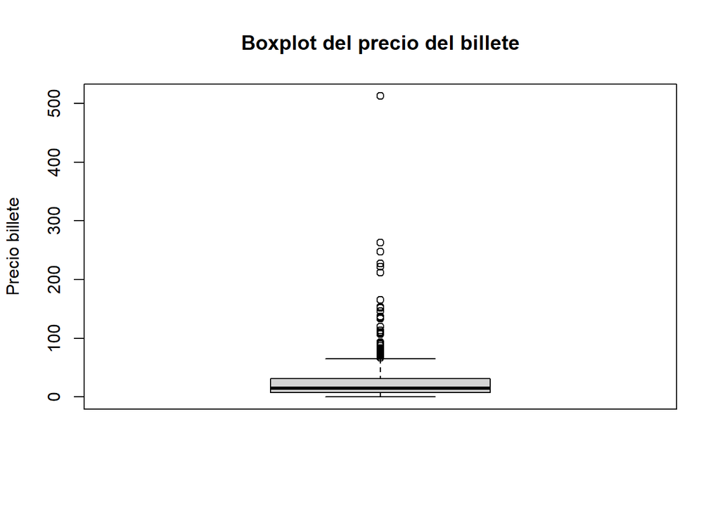

```r
boxplot(datos$Fare,
        main = "Boxplot del precio del billete",
        ylab = "Precio billete")
```

```r
# Sacamos el listado de todos los outliers
maximo <- boxplot.stats(datos$Fare)$out
maximo
```

```
##   [1]  71.2833 263.0000 146.5208  82.1708  76.7292  80.0000  83.4750  73.5000
##   [9] 263.0000  77.2875 247.5208  73.5000  77.2875  79.2000  66.6000  69.5500
##  [17]  69.5500 146.5208  69.5500 113.2750  76.2917  90.0000  83.4750  90.0000
##  [25]  79.2000  86.5000 512.3292  79.6500 153.4625 135.6333  77.9583  78.8500
##  [33]  91.0792 151.5500 247.5208 151.5500 110.8833 108.9000  83.1583 262.3750
##  [41] 164.8667 134.5000  69.5500 135.6333 153.4625 133.6500  66.6000 134.5000
##  [49] 263.0000  75.2500  69.3000 135.6333  82.1708 211.5000 227.5250  73.5000
##  [57] 120.0000 113.2750  90.0000 120.0000 263.0000  81.8583  89.1042  91.0792
##  [65]  90.0000  78.2667 151.5500  86.5000 108.9000  93.5000 221.7792 106.4250
##  [73]  71.0000 106.4250 110.8833 227.5250  79.6500 110.8833  79.6500  79.2000
##  [81]  78.2667 153.4625  77.9583  69.3000  76.7292  73.5000 113.2750  73.5000
##  [89] 512.3292 211.3375 110.8833 227.5250 151.5500 227.5250 211.3375 512.3292
##  [97]  78.8500 262.3750  71.0000  86.5000 120.0000  77.9583 211.3375  79.2000
## [105]  69.5500 120.0000  93.5000  80.0000  83.1583  69.5500  89.1042 164.8667
## [113]  69.5500  83.1583  82.2667 262.3750  76.2917 263.0000 262.3750 262.3750
## [121] 263.0000 211.5000 221.7792  78.8500 221.7792  75.2417 151.5500 262.3750
## [129]  83.1583 221.7792  83.1583  83.1583 247.5208  69.5500 134.5000 227.5250
## [137] 164.8667 211.5000  71.2833  75.2500 106.4250 134.5000 136.7792  75.2417
## [145] 136.7792  82.2667  81.8583 151.5500  93.5000 135.6333 146.5208 211.3375
## [153]  79.2000  69.5500 512.3292  73.5000  69.5500  69.5500 134.5000  81.8583
## [161] 262.3750  93.5000  79.2000 164.8667 211.5000  90.0000 108.9000
```

```r
# Sacamos el valor máximo de los outliers
max(maximo)
```

```
## [1] 512.3292
```

El **mayor valor extremo** detectado es **512.3292**, correspondiente al precio máximo de billete registrado en el dataset. Este valor es elevado en comparación con la mayoría de observaciones. A continuación, haremos alguna consulta adicional para determinar si el valor debe ser considerado como erróneo o no:

```r
# Buscaremos todos los registros donde el ticket valga 512,3292
as.data.frame(datos[datos$Fare == 512.3292, ])
```

```
##    PassengerId Survived Pclass
## 1           NA     <NA>   <NA>
## 2           NA     <NA>   <NA>
## 3           NA     <NA>   <NA>
## 4           NA     <NA>   <NA>
## 5          259      Yes      1
## 6           NA     <NA>   <NA>
## 7           NA     <NA>   <NA>
## 8           NA     <NA>   <NA>
## 9           NA     <NA>   <NA>
## 10          NA     <NA>   <NA>
## 11          NA     <NA>   <NA>
## 12          NA     <NA>   <NA>
## 13          NA     <NA>   <NA>
## 14          NA     <NA>   <NA>
```

[output cut: 84 more lines]

Al examinar los registros correspondientes en el dataset, observamos que este valor aparece asociado a cuatro pasajeros, todos ellos de primera clase y con el mismo número de ticket **(PC 17755)**. Esto nos indica que el precio corresponde a un billete compartido de alto coste **(clase 1)**, por lo que se trata de un valor extremo, pero **plausible**. En consecuencia, no se considera un error de registro y se mantiene en el conjunto de datos.

A continuación, calculareos los 10 billetes más caros:

```r
# Ordenamos los datos por Fare de mayor a menor
top_fares <- datos[order(datos$Fare, decreasing = TRUE), ]

# Mostramos los 10 primeros pasajeros
head(top_fares, 10)
```

```
## # A tibble: 10 × 13
##    PassengerId Survived Pclass Name   Sex     Age SibSp Parch Ticket  Fare Cabin
##          <dbl> <fct>    <ord>  <chr>  <fct> <dbl> <dbl> <dbl> <chr>  <dbl> <chr>
##  1         259 Yes      1      Ward,… Fema…    35     0     0 PC 17…  512. <NA>
##  2         680 Yes      1      Carde… Male     36     0     1 PC 17…  512. B51 …
##  3         738 Yes      1      Lesur… Male     35     0     0 PC 17…  512. B101
##  4        1235 Yes      1      Carde… Fema…    58     0     1 PC 17…  512. B51 …
##  5          28 No       1      Fortu… Male     19     3     2 19950   263  C23 …
##  6          89 Yes      1      Fortu… Fema…    23     3     2 19950   263  C23 …
##  7         342 Yes      1      Fortu… Fema…    24     3     2 19950   263  C23 …
##  8         439 No       1      Fortu… Male     64     1     4 19950   263  C23 …
##  9         945 Yes      1      Fortu… Fema…    28     3     2 19950   263  C23 …
## 10         961 Yes      1      Fortu… Fema…    60     1     4 19950   263  C23 …
## # ℹ 2 more variables: Embarked <fct>, FamS <dbl>
```

## 6. Correlaciones entre variables

### 6.1. Matriz de correlación

Para poder calcular la matriz de correlaciones se necesita que todos sus parámetros sean numéricos. La variable `Survived` es de tipo *factor*, por lo que será necesario crear la variable `Survived_num`, que será una conversión a *numeric* de la variable `Survived`. Me he ayudado de la web de R para la utilización de la función `ifelse` y convertir el ‘Yes - No’ en 1 y 0, respectivamente: https://stat.ethz.ch/R-manual/R-devel/library/base/html/ifelse.html

```r
# Creación variable numerica de Survived
datos$Survived_num <- ifelse(datos$Survived == "Yes", 1, 0)
```

A continuación, almacenaremos todas las columnas de las que queramos hacer la matriz de correlación en la variable `vars`. Seguidamente, calcularemos la matriz de correlación de Pearson.

```r
# Selección variables que nos interesan
vars <- datos[, c("Age","SibSp","Parch","Fare","FamS","Survived_num")]

# Cálculo de la matriz de correlación
cor(vars)
```

```
##              Age     SibSp     Parch Fare      FamS Survived_num
## Age            1        NA        NA   NA        NA           NA
## SibSp         NA 1.0000000 0.3735872   NA 0.8619518           NA
## Parch         NA 0.3735872 1.0000000   NA 0.7922957           NA
## Fare          NA        NA        NA    1        NA           NA
## FamS          NA 0.8619518 0.7922957   NA 1.0000000           NA
## Survived_num  NA        NA        NA   NA        NA            1
```

Como se puede observar, obtenemos varios ‘NAs’ en las celdas, esto ocurre cuando existen registros con valores perdidos. Para evitar este problema, se utilizará el argumento use = “complete.obs”, que calcula la correlación empleando únicamente las observaciones completas.

```r
# Cálculo de la matriz de correlación con argumento use = "complete.obs"
mat_cor <- cor(vars, use = "complete.obs")
mat_cor
```

```
##                      Age       SibSp      Parch      Fare        FamS
## Age           1.00000000 -0.24677388 -0.1349126 0.1658582 -0.23236808
## SibSp        -0.24677388  1.00000000  0.3790206 0.1407704  0.84460972
## Parch        -0.13491257  0.37902062  1.0000000 0.2226442  0.81556116
## Fare          0.16585825  0.14077041  0.2226442 1.0000000  0.21683825
## FamS         -0.23236808  0.84460972  0.8155612 0.2168383  1.00000000
## Survived_num -0.06113268  0.01033471  0.1134375 0.2360046  0.07209175
##              Survived_num
## Age           -0.06113268
## SibSp          0.01033471
## Parch          0.11343752
## Fare           0.23600455
## FamS           0.07209175
## Survived_num   1.00000000
```

Se observa una **correlación alta** entre `FamS` y:

- `SibSp` (**0.84**)
- `Parch` (**0.82**)

Esto es esperable, ya que `FamS` se define como la suma de ambas variables.

- También existe una correlación moderada entre `SibSp` y `Parch` (**0.38**). Esto nos indica que la gente que viajaba con hermanos o cónyuges, lo hacían también con otros familiares.
- Otra correlación moderada interesante se da entre las variables `Fare` y `Survived_num`, lo cual era **esperable**, ya que los tickets con mayor precio estaban mejor ubicados, dando una mayor accesibilidad a botes salvavidas.
- En cuanto a la variable `Age`, presenta **correlaciones débiles** con las variables `FamS` y `SibSp`. Esto nos indica que la gente mas mayor tendía a viajar menos con familiares.
- Como valoración de la utilización de la matriz de correlación de Pearson, **la mayoría de correlaciones observadas son bajas o moderadas**, lo cual deja claro que **no existe una dependencia lineal fuerte** entre las variables estudiadas, salvo en las relacionadas con el tamaño familiar (`FamS`, `SibSp` y `Parch`).

### 6.2. Correlación con la variable Survived

A continuación, calcularemos las variables que más correlación tienen con `Survived` (de mayor a menor):

```r
# Extraemos las correlaciones con Survived_num
cor_survived <- mat_cor[, "Survived_num"]

# Eliminamos la 'autocorrelación'
cor_survived <- cor_survived[names(cor_survived) != "Survived_num"]

# Crear un dataframe a partir del vector de correlaciones con Survived
tabla_cor_survived <- data.frame(
  # Extrae los nombres de las variables y convierte los valores de correlación a numérico
  Variable = names(cor_survived),
  Correlacion = as.numeric(cor_survived)
)
# Ordenar el data.frame en función de la correlación
tabla_cor_survived <- tabla_cor_survived[
  order(tabla_cor_survived$Correlacion, decreasing = TRUE),
]
# Creamos una tabla formateada para mostrar en el informe
kable(
  tabla_cor_survived,
  digits = 3,
  caption = "Variables ordenadas según su correlación con Survived"
) |>
  # Aplicamos estilo visual a la tabla (mediante kableExtra)
  kable_styling(
    full_width = FALSE,
    bootstrap_options = c("striped", "hover", "condensed")
  )
```

Variables ordenadas según su correlación con Survived

|  | Variable | Correlacion |
| --- | --- | --- |
| 4 | Fare | 0.236 |
| 3 | Parch | 0.113 |
| 5 | FamS | 0.072 |
| 2 | SibSp | 0.010 |
| 1 | Age | -0.061 |

## 7. Imputación de valores faltantes

En primer lugar, vamos a calcular las celdas en blanco para cada uno de las columnas:

```r
colSums(is.na(datos))
```

```
##  PassengerId     Survived       Pclass         Name          Sex          Age
##            0            3            3            0            0          264
##        SibSp        Parch       Ticket         Fare        Cabin     Embarked
##            0            0            0           28         1014            2
##         FamS Survived_num
##            0            3
```

```r
# Guardamos las filas donde Age era NA antes de imputar
filas_na <- which(is.na(datos$Age))
```

Como podemos observar, existen varias columnas que contienen el **100% de los datos**. Sin embargo, hay otras con pérdidas de información, como `Age` (**264**) o `Cabin`, donde existen hasta **1014 celdas sin valores**.

La variable `Age` se imputa mediante el algoritmo **KNN (k = 5)**.

Posteriormente, los valores se redondean al entero más cercano para: - mantener coherencia con la variable original. - facilitar la interpretación.

Este redondeo **minimiza el error medio** respecto al valor real estimado.

```r
# Importamos la librería VIM, necesaria para utilizar KNN
library(VIM)
# Creamos una tabla con las variables que nos interesan para la imputación
vars_knn <- datos[, c("Age", "SibSp", "Parch", "Fare", "FamS")]

# Imputamos la variable Age con k=5
datos_knn <- kNN(vars_knn, variable = "Age", k = 5)
```

```
##    SibSp    Parch     Fare     FamS    SibSp    Parch     Fare     FamS
##   0.0000   0.0000   0.0000   1.0000   8.0000   9.0000 512.3292  11.0000
```

```r
# Convertir Age a entero (el enunciado lo solicita). Se convierta al entero más cercano para minimizar la desviación media respecto al valor real esperado
datos_knn$Age <- round(datos_knn$Age)

# Mostramos para la variable creada las columnas 'Age' y 'Age_imp', verificando que se ha imputado la edad para los pasajeros en cuestión
head(datos_knn[filas_na, c("Age", "Age_imp")])
```

```
##    Age Age_imp
## 6   21    TRUE
## 18  32    TRUE
## 20  30    TRUE
## 27  30    TRUE
## 29  26    TRUE
## 30  33    TRUE
```

## 8. Tabla Resumen - Exportación del conjunto de datos limpio

En primer lugar, actualizamos el dataset inicial *datos* con los valores imputados:

```r
# Actualizamos la variable Age en el dataset original con los valores imputados
datos$Age <- datos_knn$Age

# Mostramos las primeras filas del dataset actualizado
head(datos)
```

```
## # A tibble: 6 × 14
##   PassengerId Survived Pclass Name    Sex     Age SibSp Parch Ticket  Fare Cabin
##         <dbl> <fct>    <ord>  <chr>   <fct> <dbl> <dbl> <dbl> <chr>  <dbl> <chr>
## 1           1 No       3      Braund… Male     22     1     0 A/5 2…  7.25 <NA>
## 2           2 Yes      1      Cuming… Fema…    38     1     0 PC 17… 71.3  C85
## 3           3 Yes      3      Heikki… Fema…    26     0     0 STON/…  7.92 <NA>
## 4           4 Yes      1      Futrel… Fema…    35     1     0 113803 53.1  C123
## 5           5 No       3      Allen,… Male     35     0     0 373450  8.05 <NA>
## 6           6 No       3      Moran,… Male     21     0     0 330877  8.46 <NA>
## # ℹ 3 more variables: Embarked <fct>, FamS <dbl>, Survived_num <dbl>
```

Las **medidas de tendencia central y dispersión** se calcularán sobre el **dataset final**, una vez realizadas todas las transformaciones, limpieza de valores erróneos y tratamiento de valores perdidos (incluyendo la imputación de la variable `Age`). Esto garantiza que los resultados obtenidos sean coherentes y representativos.

```r
# Creamos la tabla de tendencia central usando el método aggregate()
tabla_tendencia_central <- aggregate(

  # Seleccionamos las variables cuantitativas a analizar, agrupadas por Pclass y Sex
  cbind(Age, SibSp, Parch, Fare, FamS) ~ Pclass + Sex,

  # Indicamos el dataset de trabajo
  data = datos,

  # Definimos la función que se aplicará a cada variable dentro de cada grupo
  FUN = function(x) c(
    media = mean(x, na.rm = TRUE),      # Media aritmética (no robusta)
    mediana = median(x, na.rm = TRUE)   # Mediana (robusta)
  )
)
# Creamos una tabla kable con dos decimales en cada celda y los estilos especificados a continuación
kable(
  tabla_tendencia_central,
  digits = 2,
  caption = "Tabla de tendencia central por Pclass y Sex"
) |>
   kable_styling(
    full_width = FALSE,
    bootstrap_options = c("striped", "hover", "condensed")
  )
```

Tabla de tendencia central por Pclass y Sex

[output not shown]

En la tabla de tendencia central se observan **diferencias claras entre clases y sexo**.

La **edad media** es mayor en *primera clase* y menor en *tercera*, lo que sugiere que los pasajeros de clases altas eran, en general, más mayores.

A continuación, se procede a calcular las medidas de dispersión de las variables cuantitativas, agrupando por `Pclass` y `Sex`. En concreto, se emplean la **desviación estándar y la desviación absoluta respecto de la mediana (MAD)**:

```r
# Tabla de dispersión
tabla_dispersion <- aggregate(

  # Mismas variables cuantitativas que en el caso anterior
  cbind(Age, SibSp, Parch, Fare, FamS) ~ Pclass + Sex,

  # Dataset empleado
  data = datos,

  # Función de dispersión
  FUN = function(x) c(
    sd = sd(x, na.rm = TRUE),    # Desviación estándar (no robusta)
    mad = mad(x, na.rm = TRUE)   # MAD (robusta)
  )
)
# Creamos una tabla kable con dos decimales en cada celda y los estilos especificados a continuación
kable(
  tabla_dispersion,
  digits = 2,
  caption = "Tabla de dispersión por Pclass y Sex"
) |>
  kable_styling(
    full_width = FALSE,
    bootstrap_options = c("striped", "hover", "condensed")
  )
```

Tabla de dispersión por Pclass y Sex

[output not shown]

En la tabla de dispersión se observa que la variabilidad de la variable `Age` es **moderada** en todos los grupos. No obstante, la diferencia entre la **desviación estándar (sd)** y la **MAD** sugiere la posible presencia de *valores atípicos*.

Las variables familiares (`SibSp`, `Parch`, `FamS`) presentan una **dispersión muy baja**, con valores de MAD iguales a cero en numerosos casos, lo que confirma que la mayoría de los pasajeros viajaban solos.

En conjunto, la comparación entre medidas **robustas (MAD)** y **no robustas (sd)** pone de manifiesto la existencia de **distribuciones asimétricas y posibles valores atípicos (outliers)** en el conjunto de datos.

Finalmente, se exportará el dataset generado al archivo ‘**titanic_dataset_clean.xlsx**’.

```r
# Cargamos la librería necesaria
library(writexl)

# Exportamos el dataset final
write_xlsx(datos, "titanic_dataset_clean.xlsx")
```